# Text Analysis and Spatial Data for Economists

Assignment 2

Zitian Wang

08 April, 2025

```r
library(dplyr)
library(mapview)
library(sf)
library(raster)
library(readr)
library(leaflet)
```

# Raster data

## Getting raster data

For this assignment, we will use the municipality boundary and the housing price data we have already used in the last assignment.

```r
# Load here municipality boundary and housing prices from the previous assignment
municipality <- st_read("/Users/zitian/Downloads/swissboundaries3d_2025-01_2056_5728.shp/swissBOUNDARIES3D_1_5_TLM_HOHEITSGEBIET.shp")
housing_data <- read_csv("/Users/zitian/Downloads/hp_small.csv")
```

We will complement these data with two raster datasets:

- Visit https://www.swisstopo.admin.ch/en/geodata/height.html and download the *Digital Height Model 25/200* for Switzerland.
  - Read the file `DHM200.xyz` as a raster. Check its CRS and assign a value if needed. If this information is missing, retrieve the relevant CRS in the documentation and assign to your object using the function `crs(x) <- value`. Use an EPSG code as a `proj4string` definition with `"+init=epsg:MY_NUMBER"` (so the command is: `crs(x) <- "+init=epsg:MY_NUMBER"`). You will probably get warnings while assigning the CRS. This is due to a migration from `proj4string` towards `PROJ6` standards. You can ignore these warnings.

```r
# Load the file DHM200.xyz from the Digital Height Model 25/200 for Switzerland
# Assign the correct CRS if needed
dhm <- raster("/Users/zitian/Downloads/data/DHM200.xyz")
crs(dhm) <- "+init=epsg:21781"
```

```
## Warning in CPL_crs_from_input(x): GDAL Message 1: +init=epsg:XXXX syntax is
## deprecated. It might return a CRS with a non-EPSG compliant axis order.
```

- Visit https://map.geo.admin.ch and downloard the daytime road traffic noise exposure from the Federal Office for the Environment.
  - Read the file `StrassenLaerm_Tag.tif` (that is in the folder `STRASSENLAERM_Tag` that you downloaded) as a raster. Check its CRS and assign a value if needed.

```r
# Load the file StrassenLaerm_Tag.tif
noise_raster <- raster("/Users/zitian/Downloads/data (1)/STRASSENLAERM_Tag/STRASSENLAERM_Tag.tif")
```

## Raster extraction

- Assign to the housing price data the level of noise exposure for that location.

```r
# Step 1: reproject the vector object to the CRS of the raster datahousing_data_sf <- st_as_sf(
housing_data_sf <- st_as_sf(
  housing_data,
  coords = c("longitude2", "latitude2"),
  crs = 4326
)
housing_data_sf <- st_transform(housing_data_sf, crs(noise_raster))

# Step 2: extract the values for the corresponding raster's cell
housing_data_sp <- as(housing_data_sf, "Spatial")
housing_data$noise_exposure <- extract(noise_raster, housing_data_sp)
```

## Rasterization

- Rasterize the dataset on housing prices to show the average price per square meters (`a_brutm_m2`) for grids of 1,000m x 1,000m
  - Create a raster template using housing price data.
  - Convert (`a_brutm_m2`) into numeric using the functions `as.numeric(as.character(x))`

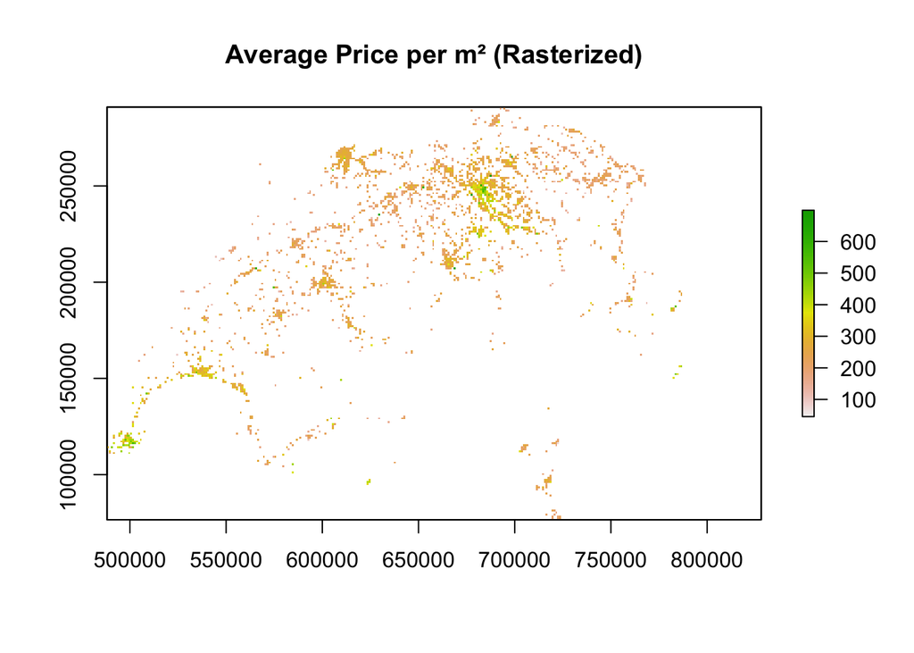

```r
# Convert factor variable into numeric
housing_data_sf$a_brutm_m2 <- as.numeric(as.character(housing_data_sf$a_brutm_m2))
# Create raster template
bbox <- st_bbox(housing_data_sf)
raster_template <- raster(xmn = bbox["xmin"],
                          xmx = bbox["xmax"],
                          ymn = bbox["ymin"],
                          ymx = bbox["ymax"],
                          res = 1000,
                          crs = st_crs(housing_data_sf)$proj4string)
# Rasterize
r_price <- rasterize(housing_data_sp, raster_template, field = "a_brutm_m2", fun = mean)
# Plot
plot(r_price, main = "Average Price per m² (Rasterized)")
```

```r
# Interactive version of the rasterized average price map
# Reproject r_price to WGS84 for interactive mapping
r_price_wgs <- projectRaster(r_price, crs = CRS("+init=epsg:4326"))
# Create a color palette for the raster values
pal_price <- colorNumeric("YlOrRd", values(r_price_wgs), na.color = "transparent")
leaflet() %>%
  addTiles() %>%
  addRasterImage(r_price_wgs, colors = pal_price, opacity = 0.8) %>%
  addLegend(pal = pal_price, values = values(r_price_wgs), title = "Average Price per m²") %>%
  setView(lng = 8.2275, lat = 46.8182, zoom = 8)
```

[interactive chart not shown]

## Spatial vectorization

- Create contour lines for 250, 500, 1000 and 2000 m.a.s.l for the digital height model. Use a mask to select only the data for Switzerland.
  - Create a polygon for Switzerland based on the municipality boundary data. Remove the z geometry using `st_zm()` and reproject the data.
  - Store the polygon as `Spatial` object (with `as(x,"Spatial")`).
  - Create a mask for the the raster data
  - Create contour lines for the desired levels (look at `?rasterToContour` to create the desired lines).

```r
# Create a polygon for Switzerland
swiss_polygon <- st_union(municipality)
swiss_polygon <- st_zm(swiss_polygon)
swiss_polygon <- st_transform(swiss_polygon, crs = st_crs(dhm))
swiss_polygon_sp <- as(swiss_polygon, "Spatial")
# Create a mask for raster data
dhm_mask <- mask(dhm, swiss_polygon_sp)
# Create contour lines
contour_levels <- c(250, 500, 1000, 2000)
contours <- rasterToContour(dhm_mask, levels = contour_levels)
```

- Create a hillshade layer to use as a basemap for the noise data

[figure not shown]

```r
# Create a hill shade layer and mask cells outside Switzerland
slope <- terrain(dhm, opt = "slope")
aspect <- terrain(dhm, opt = "aspect")
hillshade <- hillShade(slope, aspect, angle = 40, direction = 270)
hillshade <- mask(hillshade, swiss_polygon_sp)
# Plot the hillshade layer and noise data
plot(
  noise_raster,
  main = "Hillshade with Noise Data",
  legend.shrink = 0.8,
  axis.args = list(cex.axis = 0.7, las = 1)
)
```